# Relatório PL execício ilegal das profissões regulamentadas

30-09-2024

### Sumário

##### Tramitação

##### Histórico no CAU/BR

##### Possíveis ações do CAU

##### Perfil dos parlamentares

##### Anexos

## Tramitação

Há quatro PLs no Congresso Nacional sobre o exercício ilegal das profissões regulamentadas:

Na Câmara dos Deputados: [PL 3614/2015], [PL 2730/2023], [PL 3731/2023], os dois últimos foram apensados ao primeiro;

No Senado Federal: [PLS 236/2012] (novo código penal), ainda em tramitação no Senado.

Todos os PLs buscam alterar o Art. 282 do Código Penal (Decreto-Lei nº 2.848/1940), que atualmente tem a seguinte redação:

##### **Art. 282 - Exercer, ainda que a título gratuito, a profissão de médico, dentista ou farmacêutico, sem autorização legal ou excedendo-lhe os limites:**

##### **Pena - detenção, de seis meses a dois anos.**

##### **Parágrafo único - Se o crime é praticado com o fim de lucro, aplica-se também multa.**

### Tramitação na Câmara dos Deputados

- PL 3.614/2015

  Autoria: ex-deputado federal Onix Lorenzoni;

  Foi o primeiro projeto a ser apresentado;

  Tipifica como crime o exercício ilegal o exercício, sem autorização legal ou excedendo os limites, o exercício de qualquer profissão regulamentada;
- PL 2730/2023

  Autoria: deputado federal Abilio Brunini (PL/MT);

  Tipifica como crime o exercício da profissão de Engenheiro ou Arquiteto sem autorização legal ou registro no respectivo Conselho Profissional;

  Apensado ao PL 3.614/2015;
- PL 3731/2023

  Autoria: deputada federal Laura Carneiro (PSD/RJ);

  Tipifica como crime o exercício da profissão de profissão de engenheiro, arquiteto e urbanista ou engenheiro-agrônomo, sem autorização legal ou excedendo-lhes os limites.

  Apensado ao PL 3.614/2015.

A comparação em relação ao exercício com fins lucrativos, às penas e à relação com os conselhos profissionais está demonstrada a seguir:

| PL 3.614/2015 | PL 2730/2023 | PL 3731/2023 |
| --- | --- | --- |
| Se praticado com fins lucrativos, aplica-se também multa | Especifica que a prática é sonsiderada crime se exercida com fins lucrativos | Não menciona pena para prática com fins lucrativos, apenas multa |
| Reclusão, de seis meses a três anos + multa, se praticado com fins lucrativos | Detenção de seis meses a dois anos | Detenção de seis meses a dois anos + multa, se praticado com fins lucrativos |
| Não menciona explicitamente a necessidade de registro no respectivo conselho profissional | Determina que o exercício da profissão, sem autorização legal ou registro no respectivo Conselho Profissional, é crime | Determina que o exercício da profissão, sem autorização legal é crime |

O PL principal, 3.614/2015, foi encaminhado à Comissão de Constituição e Justica e de Cidadania (CCJC), onde recebeu três pareceres:

1️⃣ 2022- Deputado Tadeu Alencar (PSB/PE):

O parecer do deputado foi apresentado antes dos PLs 2730/2023 e 3731/2023 serem apensados;

O relator apresentou um parecer pela aprovação do 3.614/2015, na forma de substitutivo:

##### “Exercício ilegal de profissão regulamentada

##### Art. 282 - Exercer, ainda que a título gratuito, profissão regulamentada sujeita à fiscalização por conselho de classe, sem autorização legal ou excedendo-lhe os limites:

##### §1º A pena é aumentada de 1/3 (um terço) se o crime previsto no caput deste artigo envolver profissão relacionada à saúde humana, animal e vegetal. §2º Se o crime é praticado com o fim de lucro, aplica-se também a multa.” (NR)

O texto também trata de forma mais específica sobre o exercício da advocacia.

O parecer não foi apreciado pela comissão e Tadeu Alencar deixou de ser membro da comissão.

2️⃣ 2023- Deputado Marangoni (UNIÃO/SP):

O relator precisou apresentar três pareceres, devido aos apensados apresentados.

> <sub>O relatório deve considerar todos os apensados apresentados. Se um projeto é apensado após a apresentação do</sub>

> <sub>parecer, o relator deverá apresentar um novo relatório considerando o novo projeto</sub>

O texto substitutivo apresentado por Marangoni é quase igual ao primeiro parecer, todavia, também trata de corretores de imóveis;

O parecer não foi apreciado pela comissão e Marangoni deixou de ser membro da comissão.

3️⃣ 2024- Deputado Ricardo Salles (NOVO/SP):

O parecer de Ricardo Salles foi pela rejeição dos três projetos citados, pois seria desproporcional criminalizar o exercício ilegal das profissões regulamentadas, considerando que os conselhos já dispõem de sanções para os profissionais;

Após apresentado, o parecer foi devolvido ao relator, em razão de um novo projeto apensado;

O parecer não foi apreciado pela comissão e Ricardo Salles deixou de ser membro da comissão.

▪️ Hoje a relatora do PL é a deputada Caroline de Toni (PL/SC), que ainda não emitiu parecer sobre a matéria. Considerando seu posicionamento ideológico, a probabilidade de apresentar um parecer pela rejeição é alta, mas são necessárias conversas com a parlamentar.

### Tramitação no Senado Federal

O PLS 236/2012 aguarda parecer na Comissão de Constituição, Justiça e Cidadania (CCJ) desde 2012. Apesar de ter tido alguns relatores designados, nunca recebeu nenhum parecer.

## Histórico no CAU/BR

- 2024

  Março

  1️⃣ 37ª Reunião Ordinária do Fórum de Presidentes de CAU/UF (14/03/2024)

  O exercício ilegal da profissão foi pauta na reunião. A assessora-chefe da AIP à epoca, Luciana Rubino, apresentou os projetos de lei que tramitavam sobre o tema e informou que a aprovação de uma lei que tipifique o exercício ilegal de profissões regulamentadas não é tarefa simples, pois dificilmente será pautada no Plenário da Câmara, considerando a divisão entre os parlamentares sobre o assunto.

  O debate sobre o exercício ilegal da profissão se deu em torno, principalmente, da autoconstrução. Os debatedores apontaram que além das tragédias decorrentes da construção sem assistência técnica, há consequências menores, como falta de iluminação e circulação do ar, o que causa doenças respiratórias, falta de acessibilidade, que pode acarretar em acidentes com idosos, por exemplo, e gasto desnecessário de materiais de construção por falta de orientação qualificada.

  Nesse sentido, foi sugerida a elaboração de um material para sensibilizar os parlamentares e a sociedade a respeito da importância da aprovação de um projeto que tipifique o exercício da Arquitetura fora das condições legais como crime .

  Outros aspectos dabatidos sobre a autoconstrução foram a quantidade insuficiente de profissionais que para atenderem a alta demanda de assistência técnica, a percepção cultural sobre autoconstrução e a existência de políticas públicas que consideram autoconstrução em sua estruturação, como o caso de auxílo de compra de materiais de construção sem vínculo a algum tipo de orientação profissional.

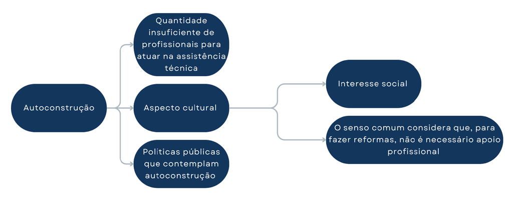

  Ainda sobre a autoconstrução, o coordenador no Fórum, presidente do CAU/TO, Matozalém Santana, destacou que na resolução 198/2020 do CAU/BR determina que:

##### Art. 39, § 1º: No caso da infração prevista no inciso V deste artigo (ausência de responsável técnico), quando o notificado ou autuado se tratar de pessoa física cuja família se configure como de baixa renda, o CAU/UF notificará o órgão local competente para o cumprimento da Lei nº 11.888, de 24 de dezembro de 2008, e, caso não seja regularizada a situação, o CAU/UF deverá comunicará o fato ao Ministério Público, não sendo aplicada a penalidade de multa ao autuado.

  Dessa forma, não se deve fazer “vista grossa” à autoconstrução diante do cenário social, pois não se trata meramente de uma questão econômica, mas de um conhecimento técnico imprescindível para esse tipo de atividade.

  Além da autoconstrução, foi mencionado o caso de estudantes de Arquitetura e Urbanismo que exercem a profissão antes de se formarem e a quantidade elevada de desing de interiores que exercem Arquitetura e Urbanismo de forma irregular. Sobre o primeiro caso, foi alertado que é importante que não seja criminalizado o exercício de todo e qualquer estudante que exerce a profissão, pois há caso em que esse exercício se dá em condição de residência. monitorado ou supervisionado por um profissional-professor.

  A presidente do CAU/MT, Elisangela Bokorni, destacou que em seu Estado há uma parceria com a Delegacia do Consumidor, que em casos de exercício irregular da prossisão, acompanha o fiscal do CAU/MT e faz a autuação, com base no Decreto-Lei 3.688/1941, Lei das Contravenções Penais.

  O presidente do CAU/PR, Maugham Zaze, destacou a importância de uma ação mais incisiva no Congresso Nacional. Nesse sentido, a ex-assessora-chefe sugeriu que o tema fosse pautado no Fórum dos Conselhos Federais das Profissões Regulamentadas, para que pudessem ganhar força e articular com a Frente Parlamentar em apoio aos Conselhos Profissionais.

  2️⃣ 146ª Plenária do CAU/BR (21/03/2024)

  O coordenador do Fórum de Presidentes, Matozalém Santana, falou a respeito da elaboração do material para sensibilização dos parlamentares e da população sobre o assunto. Também ressaltou que a maior marte da população tem acesso à moradia através da autoconstrução, o que exige cuidado no tratamento da matéria.

## Possíveis ações do CAU

Propostas de ações da 37ª Reunião Ordinária do Fórum de Presidentes de CAU/UF

Elaboração do material de sensibilização dos parlamentares e da população, indicando tragédias decorrentes da autoconstrução, problemas de iluminação e da circulação do ar, falta de acessibilidade, economia que o apoio técnico pode gerar;

Pautar o tema no Fórum dos Conselhos Federais das Profissões Regulamentadas;

Articular com a Frente Parlamentar em apoio aos Conselhos Profissionais.

Outras ações:

**É necessário que o CAU/BR aprove o texto de lei que considera adequado para o tema**;

Conversar com a relatora Caroline de Toni, para saber seu posicionamento sobre o assunto;

###### Hoje Caroline de Toni é presidente da CCJC, o que torna conseguir espaço em sua agenda difícil.

Caso a relatora seja favorável ao tema, articular no Fórum dos Conselhos Federais das Profissões Regulamentadas, para elaboração de uma proposta de parecer, para ser apresentado, em cojunto, para a relatora.

Caso a relatora seja contrária ao tema, articular com outros parlamentares Membros da Comissão de Constituição, Justiça e de Cidadania, para convencê-los sobre a importância da aprovação da matéria. Pois, em caso de apresentação de parecer pela rejeição, poderão votar por não aceitá-lo.

Caso a matéria seja aprovada na CCJC e vá ao plenário, articular com a Frente Parlamentar em apoio aos Conselhos Profissionais, para votarem de forma a aprovar o projeto.Em conjunto, será necessário articular com o Presidente da Câmara dos Deputados, para que paute a matéria.

## Perfil dos Parlamentares

### Onix Lorenzoni

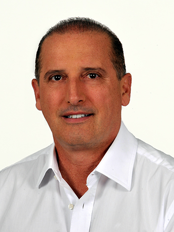

- Atividade parlamentar (Câmara dos Deputados): 2003-2022;
- Profissão: médico veterinário;
- Não é mais Deputado Federal.

###### Voltar à leitura

### Abilio Brunini (PL/MT)

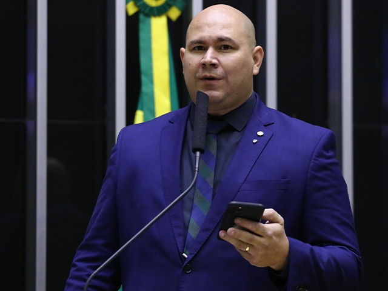

- Atividade parlamentar (Câmara dos Deputados): 2023- atual;
- Profissão: arquiteto e urbanista;
- Apesar de se alinhar a grupos liberais, tem parecer favorável ao CAU, não se opondo à regulação como outros parlamentares do grupo fazem;
- Comissões em que é titular: Comissão Externa para acompanhar a investigação da crise dos Yanomami
- Comissões em que é suplente:Comissão de Defesa dos Direitos das Pessoas com Deficiência; Comissão de Viação e Transportes; Comissão de Comunicação;Comissão de Ciência, Tecnologia e Inovação; Comissão de Desenvolvimento Urbano; Comissão de Finanças e Tributação; Comissão de Cultura; Comissão de Trabalho.

###### Voltar à leitura

### Laura Carneiro (PSD/RJ)

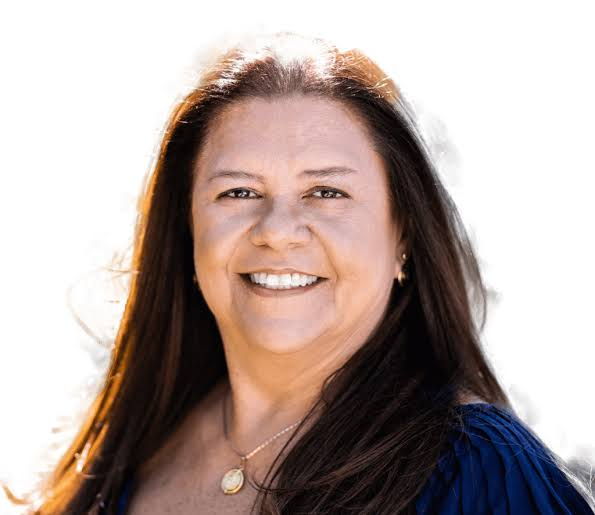

- Atividade parlamentar (Câmara dos Deputados): 2003- atual;
- Profissão: advogada;
- Já foi do PSDB, PMDB, PTB e DEM;
- Apoiou a criação de frentes parlamentares de interesse do CAU: da Engenharia, Infraestrutura e Desenvolvimento Nacional, das Micro e Pequenas Empresas; do sistema BIM e dos Conselhos Profissionais;
- Comissões em que é titular: Comissão de Defesa dos Direitos da Mulher; Comissão de Previdência, Assistência Social, Infância, Adolescência e Família; Comissões Especiais de Violência Obstétrica e Morte Materna, de Combate ao Câncer no Brasil, da PEC 169/19 - Acumulação de Cargo de Professor;
  - Comissões externas da Situação dos Municípios que Perderam Recursos do FPM e do Acidente Avião VOEPASS Linhas Aéreas - Voo 2283 - ATR-72.
- Comissões em que é suplente: Comissão de Constituição e Justiça e de Cidadania; Comissão de Finanças e Tributação.

###### Voltar à leitura

### Caroline de Toni (PL/SC)

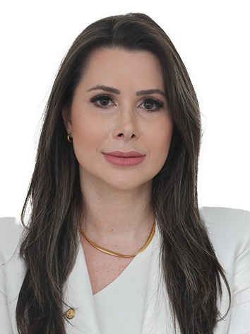

- Atividade parlamentar (Câmara dos Deputados): 2019- atual;
- Profissão: advogada;
- Considerando seu posicionamento ideológico e sua fidelidade partidária, há grandes chances de apresentar parecer pela rejeição da matéria.
- Comissões em que é titular: Comissão de Constituição e Justiça e de Cidadania; Comissão da Amazônia e dos Povos Originários e Tradicionais.
- Comissões em que é suplente: Comissão de Relações Exteriores e de Defesa Nacional.

###### Voltar à leitura

## Anexos

#### PL 3614/2015

Art. 1º O art. 282 do Decreto-lei nº 2.848, de 7 de dezembro de 1940, passa a vigorar com a seguinte redação:

“Exercício ilegal de profissão regulamentada”

Art. 282 - Exercer, ainda que a título gratuito, qualquer profissão regulamentada, sem autorização legal ou excedendo-lhe os limites:

Pena - reclusão, de seis meses a três anos. Parágrafo primeiro - Aumenta-se a pena de 1/3 (um terço) se o crime do “caput” for praticado na área da saúde humana, animal ou vegetal. Parágrafo segundo - Se o crime é praticado com o fim de lucro, aplicase também multa. (NR).

###### Voltar à leitura

#### PL 2730/2023

Art. 1º Esta Lei acrescenta dispositivos ao Decreto-Lei nº 2.848, de 7 de dezembro de 1940, para tipificar como crime o exercício ilegal da Engenharia ou Arquitetura.

Art. 2º O Decreto-Lei nº 2.848, de 7 de dezembro de 1940, passa a vigorar acrescido do seguinte artigo 282-A:

Exercício Ilegal da Engenharia ou Arquitetura

“Art. 282-A. Exercer, com fins lucrativos, a profissão de Engenheiro ou Arquiteto sem autorização legal ou registro no respectivo Conselho Profissional.

Pena: detenção de 6 (seis) meses a 2 (dois) anos”.

###### Voltar à leitura

#### PL 3731/2023

Art. 1º Esta Lei acrescenta o art. 282-A ao Decreto-lei nº 2.848, de 7 de dezembro de 1940, a fim de tipificar como crime o exercício ilegal das profissões de engenheiro, arquiteto e urbanista e engenheiro-agrônomo.

Art. 2º O Decreto-lei nº 2.848, de 7 de dezembro de 1940, passa a vigorar acrescido do seguinte art. 282-A:

“Exercício ilegal da Engenharia, da Arquitetura e Urbanismo e da Agronomia

Art. 282-A – Exercer, ainda que a título gratuito, a profissão de engenheiro, arquiteto e urbanista ou engenheiro-agrônomo, sem autorização legal ou excedendo-lhes os limites:

Pena – detenção, de seis meses a dois anos. Parágrafo único – Se o crime é praticado com o fim de lucro, aplica-se também a multa.”

###### Voltar à leitura

#### PLS 236/2012

Art. 197. Exercer ou anunciar que exerce, ainda que a título gratuito, qualquer profissão ou atividade econômica regulamentada, sem preencher as condições a que por lei está subordinado o seu exercício, ou sem autorização legal ou excedendo-lhe os limites: Pena – prisão, de seis meses a dois anos.

§ 1º Se o crime é praticado com o fim de lucro, aplica-se também multa.

§ 2º Incorre nas penas de prisão, de um a três anos, quem exercer função, atividade, direito, autoridade ou múnus de que foi suspenso ou privado por decisão administrativa ou judicial.

###### Voltar à leitura

##### Decreto-Lei 3.688/1941, Lei das Contravenções Penais

Art. 47. Exercer profissão ou atividade econômica ou anunciar que a exerce, sem preencher as condições a que por lei está subordinado o seu exercício:

Pena – prisão simples, de quinze dias a três meses, ou multa, de quinhentos mil réis a cinco contos de réis.

###### Voltar à leitura

### Comissão de Constituição, Justiça e de Cidadania

- Titulares: Acácio Favacho (MDB/AP), Afonso Motta (PDT/RS), Alex Manente (CIDADANIA/SP), Alfredo Gaspar (UNIÃO/AL), Allan Garcês (PP/MA), Arthur Oliveira Maia (UNIÃO/BA), Bacelar (PV/BA), Bia Kicis (PL/DF), Capitão Alberto Neto (PL/AM), Caroline de Toni (PL/SC), Castro Neto (PSD/PI), Cezinha de Madureira (PSD/SP), Chris Tonietto (PL/RJ), Coronel Assis (UNIÃO/MT), Coronel Fernanda (PL/MT), Covatti Filho (PP/RS), Danilo Forte (UNIÃO/CE), Defensor Stélio Dener (REPUBLICANOS/RR), Delegada Katarina (PSD/SE), Delegado Fabio Costa (PP/AL), Delegado Éder Mauro (PL/PA), Diego Coronel (PSD/BA), Dr. Jaziel (PL/CE), Dr. Victor Linhalis (PODE/ES), Duarte Jr. (PSB/MA), Eduardo Bismarck (PDT/CE), Elcione Barbalho (MDB/PA), Eliza Virgínia (PP/PB), Felipe Carreras (PSB/PE), Fernanda Pessoa (UNIÃO/CE), Fernando Rodolfo (PL/PE), Flávio Nogueira (PT/PI), Helder Salomão (PT/ES), José Guimarães (PT/CE), João Leão (PP/BA), Juarez Costa (MDB/MT), Julia Zanatta (PL/SC), Lafayette de Andrada (REPUBLICANOS/MG), Luiz Couto (PT/PB), Luiz Philippe de Orleans e Bragança (PL/SP), Marcelo Crivella (REPUBLICANOS/RJ), Marcos Pollon (PL/MS), Marcos Soares (UNIÃO/RJ), Maria Arraes (SOLIDARIEDADE/PE), Marreca Filho (PRD/MA), Mauricio Marcon (PODE/RS), Mendonça Filho (UNIÃO/PE), Nicoletti (UNIÃO/RR), Olival Marques (MDB/PA), Orlando Silva (PCdoB/SP), Patrus Ananias (PT/MG), Paulo Abi-ackel (PSDB/MG), Paulo Magalhães (PSD/BA), Pedro Aihara (PRD/MG), Pedro Lupion (PP/PR), Pr. Marco Feliciano (PL/SP), Renilce Nicodemos (MDB/PA), Renildo Calheiros (PCdoB/PE), Ricardo Ayres (REPUBLICANOS/TO), Roberto Duarte (REPUBLICANOS/AC), Rubens Pereira Júnior (PT/MA), Soraya Santos (PL/RJ), Waldemar Oliveira (AVANTE/PE), Welter (PT/PR), Chico Alencar (PSOL/RJ), Célia Xakriabá (PSOL/MG).
- Suplentes: Aguinaldo Ribeiro (PP/PB), Alencar Santana (PT/SP), Aluisio Mendes (REPUBLICANOS/MA), Ana Paula Lima (PT/SC), Aureo Ribeiro (SOLIDARIEDADE/RJ), Baleia Rossi (MDB/SP), Benes Leocádio (UNIÃO/RN), Bruno Farias (AVANTE/MG), Cabo Gilberto Silva (PL/PB), Carlos Veras (PT/PE), Cobalchini (MDB/SC), Coronel Meira (PL/PE), Dandara (PT/MG), Dani Cunha (UNIÃO/RJ), Daniel José (PODE/SP), Darci de Matos (PSD/SC), Delegado Marcelo Freitas (UNIÃO/MG), Delegado Paulo Bilynskyj (PL/SP), Delegado Ramagem (PL/RJ), Delegado da Cunha (PP/SP), Diego Garcia (REPUBLICANOS/PR), Domingos Sávio (PL/MG), Emanuel Pinheiro Neto (MDB/MT), Erika Kokay (PT/DF), Evair Vieira de Melo (PP/ES), Felipe Francischini (UNIÃO/PR), Filipe Barros (PL/PR), Gilson Daniel (PODE/ES), Gisela Simona (UNIÃO/MT), Gleisi Hoffmann (PT/PR), Hugo Motta (REPUBLICANOS/PB), José Medeiros (PL/MT), Kiko Celeguim (PT/SP), Kim Kataguiri (UNIÃO/SP), Laura Carneiro (PSD/RJ), Lindbergh Farias (PT/RJ), Lucas Redecker (PSDB/RS), Lucyana Genésio (PDT/MA), Luiz Gastão (PSD/CE), Lêda Borges (PSDB/GO), Marcelo Moraes (PL/RS), Mauro Benevides Filho (PDT/CE), Miguel Ângelo (PT/MG), Pauderney Avelino (UNIÃO/AM), Paulo Azi (UNIÃO/BA), Pedro Campos (PSB/PE), Pedro Jr (PL/TO), Rafael Brito (MDB/AL), Rafael Simoes (UNIÃO/MG), Reginaldo Lopes (PT/MG), Rodolfo Nogueira (PL/MS), Rodrigo Valadares (UNIÃO/SE), Ronaldo Nogueira (REPUBLICANOS/RS), Sergio Souza (MDB/PR), Sidney Leite (PSD/AM), Tabata Amaral (PSB/SP), Tião Medeiros (PP/PR), Toninho Wandscheer (PP/PR), Wilson Santiago (REPUBLICANOS/PB), Zucco (PL/RS), Zé Haroldo Cathedral (PSD/RR), Átila Lira (PP/PI), Sâmia Bomfim (PSOL/SP), Túlio Gadêlha (REDE/PE), Gilson Marques (NOVO/SC), Marcel Van Hattem (NOVO/RS).

###### Voltar à leitura